# SEMANA 12: DIAGRAMA DE DISPERSIÓN. INTERPRETACIÓN

Daniel Escriba Flores

2025-06-09

# Caso 1

Supongamos que tenemos la intención de volvernos socios de una tienda de electrodomésticos; para estar seguros de la decisión, queremos estimar cómo será el crecimiento de los ingresos (en soles) para el próximo año. A continuación, se muestran los datos de los últimos años:

Tabla de datos

| Año | Ingresos |
| --- | --- |
| 2007 | 45000 |
| 2008 | 60000 |
| 2009 | 80000 |
| 2010 | 110000 |
| 2011 | 150000 |
| 2012 | 200000 |
| 2013 | 260000 |
| 2014 | 350000 |
| 2015 | 500000 |
| 2016 | 750000 |

Con respecto a lo anterior, haga lo siguiente:

## Pregunta A: Datos y Dispersion

Lea la base de datos y elabore un diagrama de dispersión. Incluya diferentes parámetros para los colores, título del gráfico, nombre de los ejes, tipo de marca y tamaño.

### Lectura de datos

```r
library(readxl)

data = read_excel("Lab12.xlsx", sheet="P1")
data= as.data.frame(data)
data
```

| Año | Ingresos |
| --- | --- |
| 2007 | 45000 |
| 2008 | 60000 |
| 2009 | 80000 |
| 2010 | 110000 |
| 2011 | 150000 |
| 2012 | 200000 |
| 2013 | 260000 |
| 2014 | 350000 |
| 2015 | 500000 |
| 2016 | 750000 |

### Diagrama con parametros

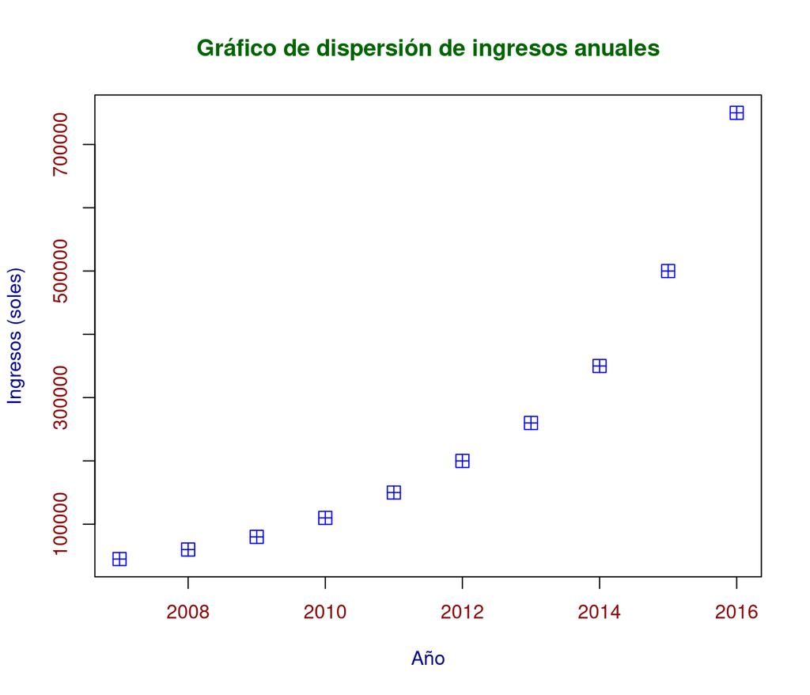

```r
# Crear el diagrama de dispersión
plot(data,
     pch=12,          # Tipo de marca: círculo sólido
     col="blue",      # Color de las marcas
     cex=1.5,         # Tamaño de las marcas
     main="Gráfico de dispersión de ingresos anuales",  # Título del gráfico
     xlab="Año",      # Nombre del eje X
     ylab="Ingresos (soles)",  # Nombre del eje Y
     col.main="darkgreen",  # Color del título
     col.lab="darkblue",    # Color de los nombres de los ejes
     col.axis="darkred")    # Color de los ejes
```

## Pregunta B: Grupos y Dispersion

Separe los datos en dos grupos considerando a uno de ellos del año 2012 hacia adelante. Luego, elabore un diagrama de dispersión que muestre dichos grupos incluyendo diferentes parámetros gráficos.

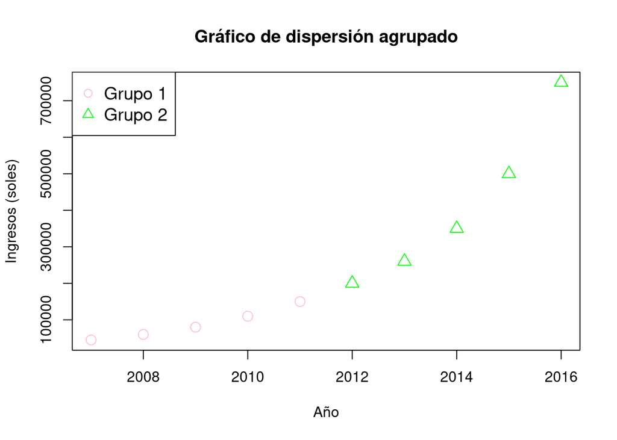

```r
# Crear un factor para los grupos
grupo <- as.factor(ifelse(data$Año < 2012, "Grupo 1", "Grupo 2"))

# Definir colores para los grupos
colores <- c("pink", "green")

# Crear el diagrama de dispersión
plot(data$Año, data$Ingresos,
     pch=as.numeric(grupo),
     col=colores[grupo],
     cex=1.5,
     main="Gráfico de dispersión agrupado",
     xlab="Año",
     ylab="Ingresos (soles)")

# Agregar leyenda
legend("topleft",
       legend=c("Grupo 1", "Grupo 2"),
       pch=c(1, 2),
       col=colores,
       cex=1.2)
```

# Caso 2

Un agrónomo diseñó un estudio en el que se cultivaron tomates utilizando seis cantidades distintas de fertilizante: 0, 20, 40, 60, 80 y 100 libras por cada 1000 pies cuadrados. Estos índices de aplicación de fertilizante se asignaron de manera aleatoria a parcelas de tierra que arrojaron la siguiente producción de tomate (en libras):

Tabla de datos

| Indice | Rendimiento |
| --- | --- |
| 0 | 6 |
| 0 | 9 |
| 20 | 19 |
| 20 | 24 |
| 40 | 32 |
| 40 | 38 |
| 60 | 46 |
| 60 | 50 |
| 80 | 48 |
| 80 | 54 |
| 100 | 52 |
| 100 | 58 |

Con respecto a lo anterior, haga lo siguiente:

## Pregunta A: Datos y Dispersion

Lea la base de datos y elabore un diagrama de dispersión. Incluya diferentes parámetros para los colores, título del gráfico, nombre de los ejes, tipo de marca y tamaño.

### Lectura de datos

```r
library(readxl)

data1 = read_excel("Lab12.xlsx", sheet="P2")
data1= as.data.frame(data1)
data1
```

| Indice | Rendimiento |
| --- | --- |
| 0 | 6 |
| 0 | 9 |
| 20 | 19 |
| 20 | 24 |
| 40 | 32 |
| 40 | 38 |
| 60 | 46 |
| 60 | 50 |
| 80 | 48 |
| 80 | 54 |

[output cut: 2 more lines]

### Diagrama con parametros

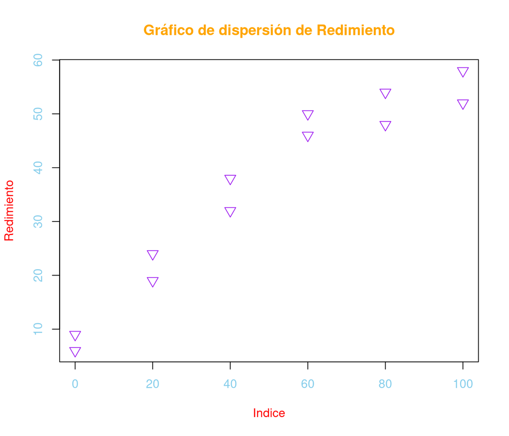

```r
# Crear el diagrama de dispersión
plot(data1,
     pch=25,          # Tipo de marca: círculo sólido
     col="purple",      # Color de las marcas
     cex=1.5,         # Tamaño de las marcas
     main="Gráfico de dispersión de Redimiento",  # Título del gráfico
     xlab=" Indice ",      # Nombre del eje X
     ylab="Redimiento",  # Nombre del eje Y
     col.main="orange",  # Color del título
     col.lab="red",    # Color de los nombres de los ejes
     col.axis="skyblue")    # Color de los ejes
```

## Pregunta B: Grupos y Dispersion

Separe los datos en dos grupos considerando a uno de ellos con índice de aplicación de fertilizante de 60 hacia adelante. Luego, elabore un diagrama de dispersión que muestre dichos grupos incluyendo diferentes parámetros gráficos.

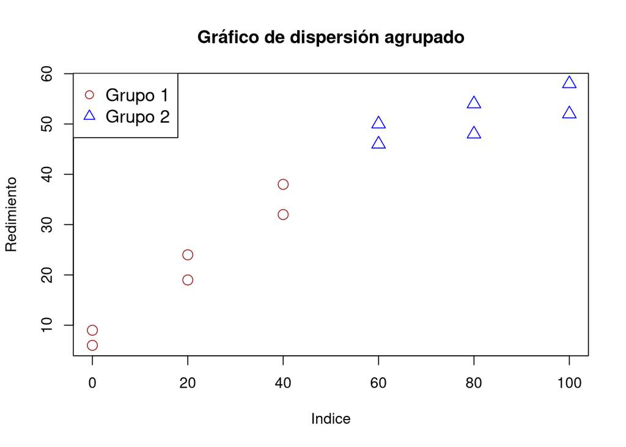

```r
# Crear un factor para los grupos
grupo <- as.factor(ifelse(data1$Indice < 60, "Grupo 1", "Grupo 2"))

# Definir colores para los grupos
colores <- c("brown", "blue")

# Crear el diagrama de dispersión
plot(data1$Indice, data1$Rendimiento,
     pch=(as.numeric(grupo)),
     col=colores[grupo],
     cex=1.5,
     main="Gráfico de dispersión agrupado",
     xlab="Indice",
     ylab="Redimiento")

# Agregar leyenda
legend("topleft",
       legend=c("Grupo 1", "Grupo 2"),
       pch=c(1, 2),
       col=colores,
       cex=1.2)
```